# Database No Show Appointments

```python
def autolabel(ax, spacing=5):
    """Add labels to the end of each bar in a bar chart.

    Arguments:
        ax (matplotlib.axes.Axes): The matplotlib object containing the axes
            of the plot to annotate.
        spacing (int): The distance between the labels and the bars.
    """

    # For each bar: Place a label
    for rect in ax.patches:
        # Get X and Y placement of label from rect.
        y_value = rect.get_height()
        x_value = rect.get_x() + rect.get_width() / 2

        # Number of points between bar and label. Change to your liking.
        space = spacing
        # Vertical alignment for positive values
        va = 'bottom'

        # If value of bar is negative: Place label below bar
        if y_value < 0:
            # Invert space to place label below
            space *= -1
            # Vertically align label at top
            va = 'top'

        # Use Y value as label and format number with one decimal place
        label = "{:.2f}".format(y_value)

        # Create annotation
        ax.annotate(
            label,                      # Use `label` as label
            (x_value, y_value),         # Place label at end of the bar
            xytext=(0, space),          # Vertically shift label by `space`
            textcoords="offset points", # Interpret `xytext` as offset in points
            ha='center',                # Horizontally center label
            va=va)                      # Vertically align label differently for
                                        # positive and negative values.
```

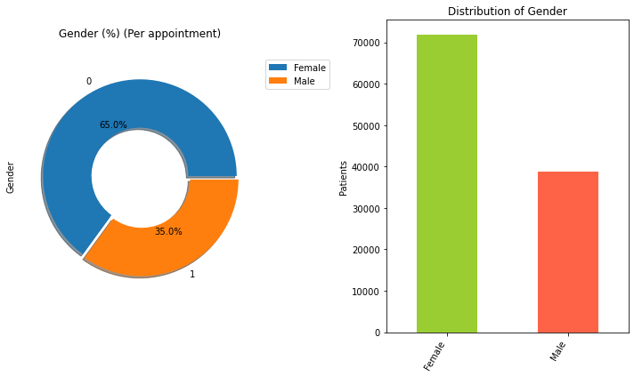

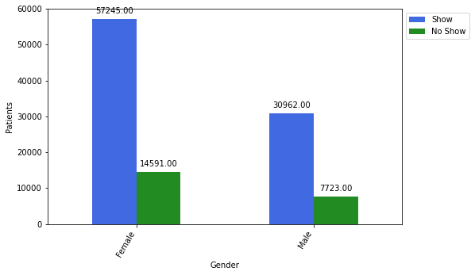

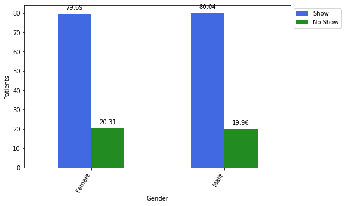

```python
## Plotting gender distribution
fig = plt.subplots(figsize=(10,6))

plt.subplot(1,2,1)
df_pie = (df['Gender'].value_counts()/100)
ax1 = df_pie.plot.pie(shadow=True, explode=(0, 0.04), autopct='%1.1f%%',wedgeprops=dict(width=0.5))
ax1.set_title('Gender (%) (Per appointment)\n');
ax1.legend(labels=['Female','Male'],loc = 'upper left',bbox_to_anchor=(1.0,1.0))

plt.subplot(1,2,2)
df_bar = df['Gender'].value_counts()
ax2 = df_bar.plot.bar(color=['yellowgreen','tomato'])
ax2.set_xticklabels(["Female", "Male"], rotation=60, ha="right")
ax2.set_ylabel("Patients")
ax2.set_title('Distribution of Gender')
plt.tight_layout()
plt.show()

df_count = pd.crosstab(df['Gender'], df['No_show'])
ax3 = df_count.plot.bar(figsize=(8,5), color=['royalblue','forestgreen'])
ax3.set_xticklabels(['Female','Male'], rotation=60, ha="right")
ax3.set_ylabel("Patients")
ax3.legend(labels=['Show', 'No Show'],loc = 'upper left',bbox_to_anchor=(1.0,1.0))
autolabel(ax3)

df_count = pd.crosstab(df['Gender'], df['No_show'], normalize = 'index')*100
ax4 = df_count.plot.bar(figsize=(8,5), color=['royalblue','forestgreen'])
ax4.set_xticklabels(['Female','Male'], rotation=60, ha="right")
ax4.set_ylabel("Patients")
ax4.legend(labels=['Show', 'No Show'],loc = 'upper left',bbox_to_anchor=(1.0,1.0))
autolabel(ax4)

plt.show()
```

- Appointment proportion where patients are females is 65%, where the proportion of appointments where patients are males is 35%.
- Show-up rate of male patients (per no. of appointments) is slightly greater than the show-up rate of female patients.

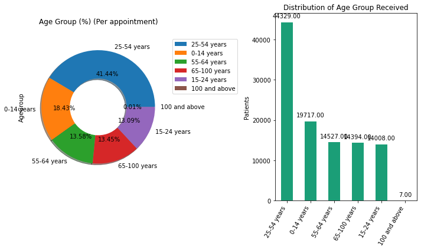

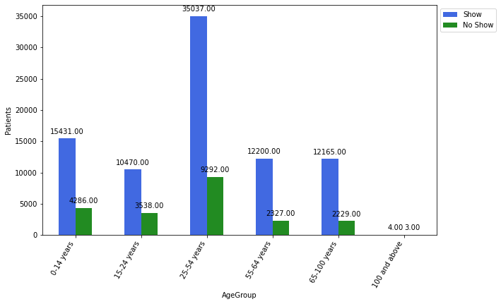

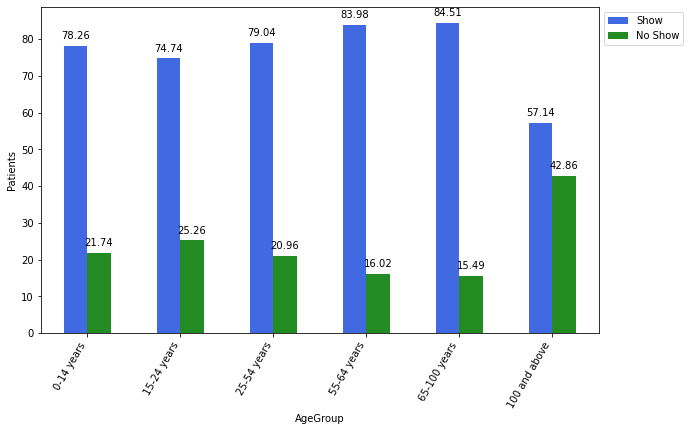

```python
### Plotting Age Group distribution

fig = plt.subplots(figsize=(10,6))

plt.subplot(1,2,1)
df_pie = (df['AgeGroup'].value_counts()/100)
ax1 = df_pie.plot.pie(shadow=True ,autopct='%1.2f%%',wedgeprops=dict(width=0.5))
ax1.set_title('Age Group (%) (Per appointment)\n');
ax1.legend(loc = 'upper left',bbox_to_anchor=(1.0,1.0))

plt.subplot(1,2,2)
df_bar = df['AgeGroup'].value_counts()
ax2 = df_bar.plot.bar(cmap='Dark2')
ax2.set_xticklabels(ax2.get_xticklabels(), rotation=60, ha="right")
ax2.set_ylabel("Patients")
ax2.set_title('Distribution of Age Group Received')
autolabel(ax2)
plt.tight_layout()
plt.show()

df_count = pd.crosstab(df['AgeGroup'], df['No_show'])
ax3 = df_count.plot.bar(figsize=(10,6), color=['royalblue','forestgreen'])
ax3.set_xticklabels(ax3.get_xticklabels(), rotation=60, ha="right")
ax3.set_ylabel("Patients")
ax3.legend(labels=['Show', 'No Show'],loc = 'upper left',bbox_to_anchor=(1.0,1.0))
autolabel(ax3)

df_count = pd.crosstab(df['AgeGroup'], df['No_show'], normalize = 'index')*100
ax4 = df_count.plot.bar(figsize=(10,6), color=['royalblue','forestgreen'])
ax4.set_xticklabels(ax3.get_xticklabels(), rotation=60, ha="right")
ax4.set_ylabel("Patients")
ax4.legend(labels=['Show', 'No Show'],loc = 'upper left',bbox_to_anchor=(1.0,1.0))
autolabel(ax4)

plt.show()
```

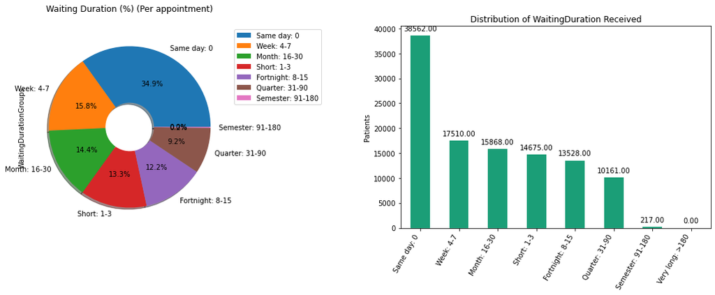

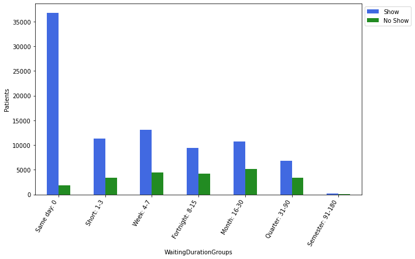

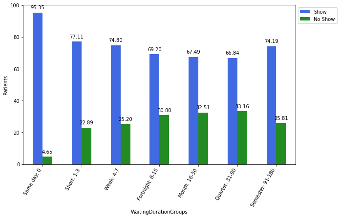

```python
# Plotting Waiting Duration
fig = plt.subplots(figsize=(15,6))

plt.subplot(1,2,1)
df_pie = (df['WaitingDurationGroups'].value_counts()/100)
ax1 = df_pie.plot.pie(shadow=True,wedgeprops=dict(width=0.7), autopct='%1.1f%%')
ax1.set_title('Waiting Duration (%) (Per appointment)\n');
ax1.legend(loc = 'upper left',bbox_to_anchor=(1.0,1.0))

plt.subplot(1,2,2)
df_bar = df['WaitingDurationGroups'].value_counts()
ax2 = df_bar.plot.bar(cmap='Dark2')
ax2.set_xticklabels(ax2.get_xticklabels(), rotation=60, ha="right")
ax2.set_ylabel("Patients")
ax2.set_title('Distribution of WaitingDuration Received')
autolabel(ax2)
plt.tight_layout()
plt.show()

df_count = pd.crosstab(df['WaitingDurationGroups'], df['No_show'])
ax3 = df_count.plot.bar(figsize=(10,6), color=['royalblue','forestgreen'])
ax3.set_xticklabels(ax3.get_xticklabels(), rotation=60, ha="right")
ax3.set_ylabel("Patients")
ax3.legend(labels=['Show', 'No Show'],loc = 'upper left',bbox_to_anchor=(1.0,1.0))

df_count = pd.crosstab(df['WaitingDurationGroups'], df['No_show'], normalize = 'index')*100
ax4 = df_count.plot.bar(figsize=(10,6), color=['royalblue','forestgreen'])
ax4.set_xticklabels(ax3.get_xticklabels(), rotation=60, ha="right")
ax4.set_ylabel("Patients")
ax4.legend(labels=['Show', 'No Show'],loc = 'upper left',bbox_to_anchor=(1.0,1.0))
autolabel(ax4)

plt.show()
```

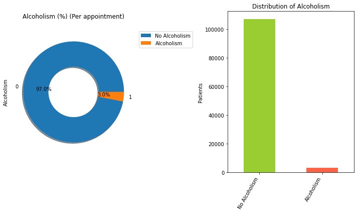

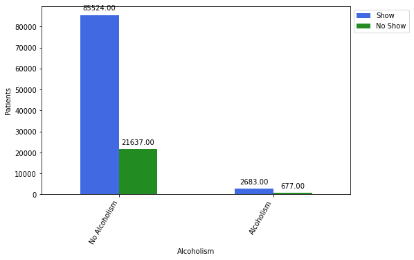

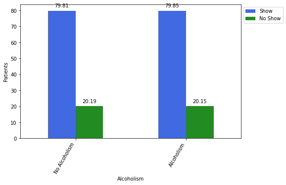

```python
## Plotting Alcoholism distribution
fig = plt.subplots(figsize=(10,6))

plt.subplot(1,2,1)
df_pie = (df['Alcoholism'].value_counts()/100)
ax1 = df_pie.plot.pie(shadow=True, autopct='%1.1f%%',wedgeprops=dict(width=0.5))
ax1.set_title('Alcoholism (%) (Per appointment)\n');
ax1.legend(labels=["No Alcoholism", "Alcoholism"], loc = 'upper left',bbox_to_anchor=(1.0,1.0))

plt.subplot(1,2,2)
df_bar = df['Alcoholism'].value_counts()
ax2 = df_bar.plot.bar(color=['yellowgreen','tomato'])
ax2.set_xticklabels(["No Alcoholism", "Alcoholism"], rotation=60, ha="right")
ax2.set_ylabel("Patients")
ax2.set_title('Distribution of Alcoholism')
plt.tight_layout()
plt.show()

df_count = pd.crosstab(df['Alcoholism'], df['No_show'])
ax3 = df_count.plot.bar(figsize=(8,5), color=['royalblue','forestgreen'])
ax3.set_xticklabels(["No Alcoholism", "Alcoholism"], rotation=60, ha="right")
ax3.set_ylabel("Patients")
ax3.legend(labels=['Show', 'No Show'], loc = 'upper left',bbox_to_anchor=(1.0,1.0))
autolabel(ax3)

df_count = pd.crosstab(df['Alcoholism'], df['No_show'], normalize = 'index')*100
ax4 = df_count.plot.bar(figsize=(8,5), color=['royalblue','forestgreen'])
ax4.set_xticklabels(["No Alcoholism", "Alcoholism"], rotation=60, ha="right")
ax4.set_ylabel("Patients")
ax4.legend(labels=['Show', 'No Show'], loc = 'upper left',bbox_to_anchor=(1.0,1.0))
autolabel(ax4)

plt.show()
```

### Research Question 4 . Did the Brazilian social welfare programme Bolsa Familia have an impact on patient visits?

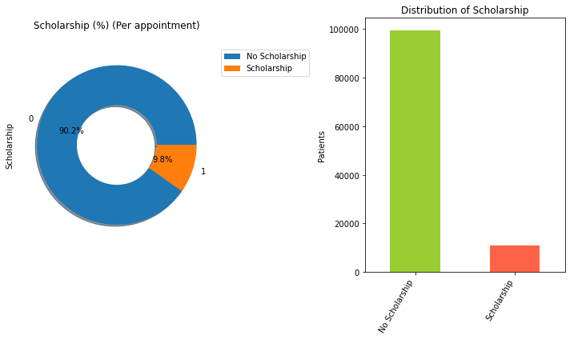

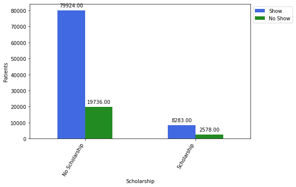

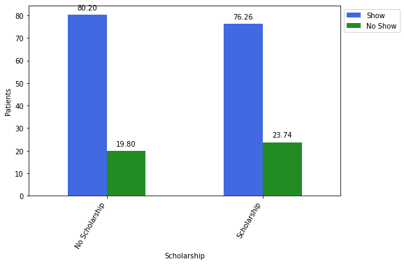

```python
## Plotting Scholarship distribution
fig = plt.subplots(figsize=(10,6))

plt.subplot(1,2,1)
df_pie = (df['Scholarship'].value_counts()/100)
ax1 = df_pie.plot.pie(shadow=True, autopct='%1.1f%%',wedgeprops=dict(width=0.5))
ax1.set_title('Scholarship (%) (Per appointment)\n');
ax1.legend(labels=["No Scholarship", "Scholarship"],loc = 'upper left',bbox_to_anchor=(1.0,1.0))

plt.subplot(1,2,2)
df_bar = df['Scholarship'].value_counts()
ax2 = df_bar.plot.bar(color=['yellowgreen','tomato'])
ax2.set_xticklabels(["No Scholarship", "Scholarship"], rotation=60, ha="right")
ax2.set_ylabel("Patients")
ax2.set_title('Distribution of Scholarship')
plt.tight_layout()
plt.show()

df_count = pd.crosstab(df['Scholarship'], df['No_show'])
ax3 = df_count.plot.bar(figsize=(8,5), color=['royalblue','forestgreen'])
ax3.set_xticklabels(["No Scholarship", "Scholarship"], rotation=60, ha="right")
ax3.set_ylabel("Patients")
ax3.legend(labels=['Show', 'No Show'],loc = 'upper left',bbox_to_anchor=(1.0,1.0))
autolabel(ax3)

df_count = pd.crosstab(df['Scholarship'], df['No_show'], normalize = 'index')*100
ax4 = df_count.plot.bar(figsize=(8,5), color=['royalblue','forestgreen'])
ax4.set_xticklabels(["No Scholarship", "Scholarship"], rotation=60, ha="right")
ax4.set_ylabel("Patients")
ax4.legend(labels=['Show', 'No Show'],loc = 'upper left',bbox_to_anchor=(1.0,1.0))
autolabel(ax4)

plt.show()
```

- 90.2% of the patients don't have a scholarship, where only 9.8% of the patients have been granted a scholarship.
- Patients with no scholarship (90.2% of the total population) have the highest show-up rate of 80.2% (higher than the average show-up rate), where those with scholarships (9.8% of the total population) have a show-up rate of 76.26% (lower than the average show-up rate).

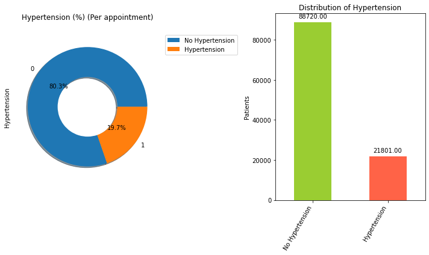

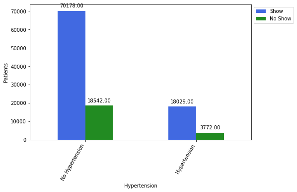

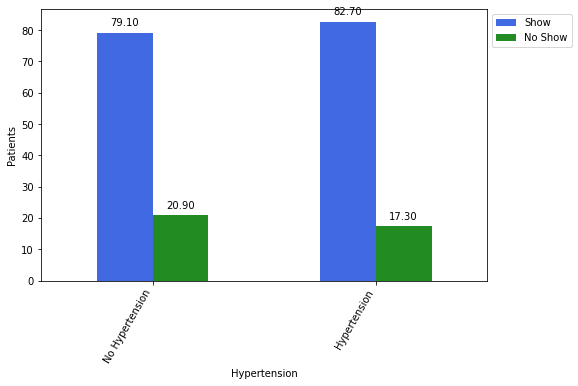

```python
## Plotting Hypertension distribution
fig = plt.subplots(figsize=(10,6))

plt.subplot(1,2,1)
df_pie = (df['Hypertension'].value_counts()/100)
ax1 = df_pie.plot.pie(shadow=True, autopct='%1.1f%%',wedgeprops=dict(width=0.5))
ax1.set_title('Hypertension (%) (Per appointment)\n');
ax1.legend(labels=["No Hypertension", "Hypertension"],loc = 'upper left',bbox_to_anchor=(1.0,1.0))

plt.subplot(1,2,2)
df_bar = df['Hypertension'].value_counts()
ax2 = df_bar.plot.bar(color=['yellowgreen','tomato'])
ax2.set_xticklabels(["No Hypertension", "Hypertension"], rotation=60, ha="right")
ax2.set_ylabel("Patients")
ax2.set_title('Distribution of Hypertension')
autolabel(ax2)
plt.tight_layout()

df_count = pd.crosstab(df['Hypertension'], df['No_show'])
ax3 = df_count.plot.bar(figsize=(8,5), color=['royalblue','forestgreen'])
ax3.set_xticklabels(["No Hypertension", "Hypertension"], rotation=60, ha="right")
ax3.set_ylabel("Patients")
ax3.legend(labels=['Show', 'No Show'],loc = 'upper left',bbox_to_anchor=(1.0,1.0))
autolabel(ax3)

df_count = pd.crosstab(df['Hypertension'], df['No_show'], normalize = 'index')*100
ax4 = df_count.plot.bar(figsize=(8,5), color=['royalblue','forestgreen'])
ax4.set_xticklabels(["No Hypertension", "Hypertension"], rotation=60, ha="right")
ax4.set_ylabel("Patients")
ax4.legend(labels=['Show', 'No Show'],loc = 'upper left',bbox_to_anchor=(1.0,1.0))
autolabel(ax4)

plt.show()
```

- Patients have no hypertension is 80.3%, where patients have hypertension is 19.7%.
- Show-up rate of patients who have hypertension is the highest with 82.7%, where the show-up rate of patients who dont'have hypertension is 79.1%

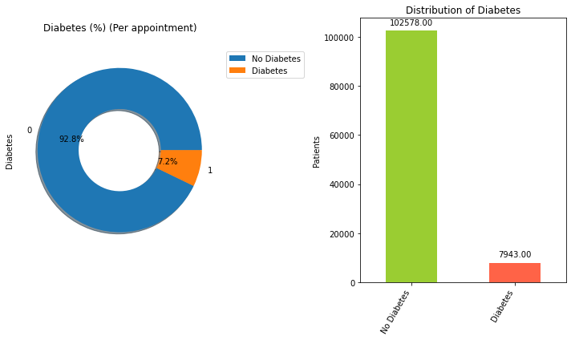

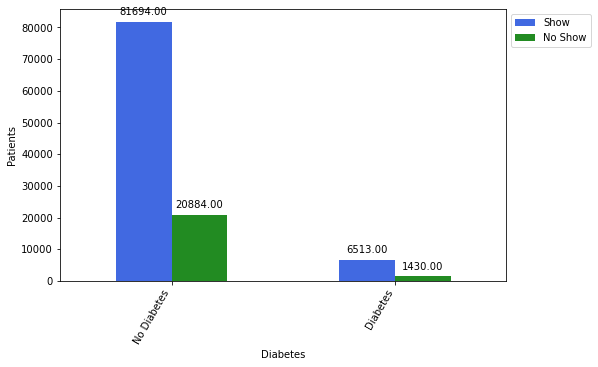

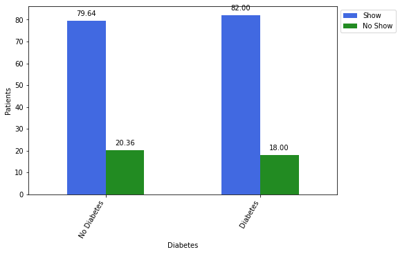

```python
### Plotting Diabetes distribution
fig = plt.subplots(figsize=(10,6))

plt.subplot(1,2,1)
df_pie = (df['Diabetes'].value_counts()/100)
ax1 = df_pie.plot.pie(shadow=True, autopct='%1.1f%%',wedgeprops=dict(width=0.5))
ax1.set_title('Diabetes (%) (Per appointment)\n');
ax1.legend(labels=["No Diabetes", "Diabetes"],loc = 'upper left',bbox_to_anchor=(1.0,1.0))

plt.subplot(1,2,2)
df_bar = df['Diabetes'].value_counts()
ax2 = df_bar.plot.bar(color=['yellowgreen','tomato'])
ax2.set_xticklabels(["No Diabetes", "Diabetes"], rotation=60, ha="right")
ax2.set_ylabel("Patients")
ax2.set_title('Distribution of Diabetes')
autolabel(ax2)
plt.tight_layout()
plt.show()

df_count = pd.crosstab(df['Diabetes'], df['No_show'])
ax3 = df_count.plot.bar(figsize=(8,5), color=['royalblue','forestgreen'])
ax3.set_xticklabels(["No Diabetes", "Diabetes"], rotation=60, ha="right")
ax3.set_ylabel("Patients")
ax3.legend(labels=['Show', 'No Show'],loc = 'upper left',bbox_to_anchor=(1.0,1.0))
autolabel(ax3)

df_count = pd.crosstab(df['Diabetes'], df['No_show'], normalize = 'index')*100
ax4 = df_count.plot.bar(figsize=(8,5), color=['royalblue','forestgreen'])
ax4.set_xticklabels(["No Diabetes", "Diabetes"], rotation=60, ha="right")
ax4.set_ylabel("Patients")
ax4.legend(labels=['Show', 'No Show'],loc = 'upper left',bbox_to_anchor=(1.0,1.0))
autolabel(ax4)

plt.show()
```

- We find that 92.8% of the patients don't have diabetes, where patients have diabetes is 7.19%.
- Show-up rate of patients who have diabetes is the highest with 82%, where the show-up rate of patients who don't have diabetes is 79.64%

```
0    97.974141
1     1.845803
2     0.165579
3     0.011762
4     0.002714
Name: Handicap, dtype: float64
```

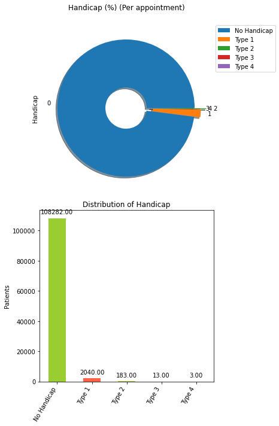

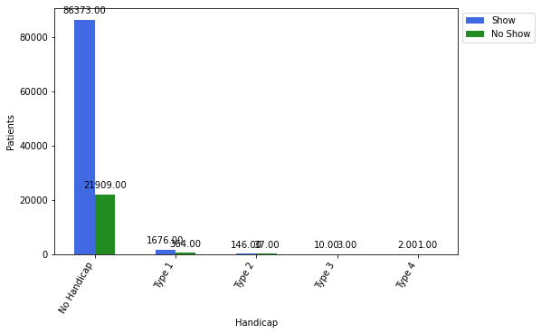

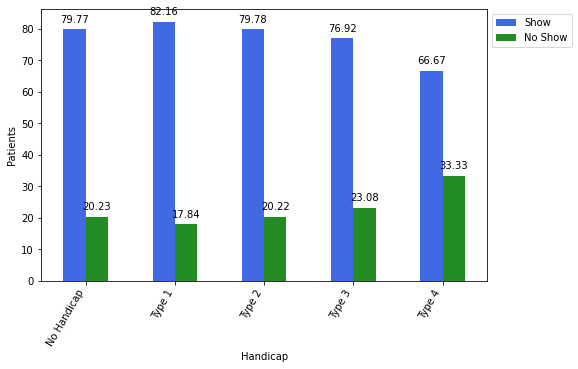

```python
### Plotting Handicap Distribution
fig = plt.subplots(figsize=(6,10))

plt.subplot(2,1,1)
df_pie = (df['Handicap'].value_counts()/100)
print((df_pie/df_pie.sum())*100)

ax1 = df_pie.plot.pie(shadow=True, explode= (0.01, 0.08, 0.16, 0.05, 0.09),wedgeprops=dict(width=0.7))
ax1.set_title('Handicap (%) (Per appointment)\n');
ax1.legend(labels=["No Handicap", "Type 1", "Type 2", "Type 3", "Type 4"],loc = 'upper left',bbox_to_anchor=(1.0,1.0))

plt.subplot(2,1,2)
df_bar = df['Handicap'].value_counts()
ax2 = df_bar.plot.bar(color=['yellowgreen','tomato'])
ax2.set_xticklabels(["No Handicap", "Type 1", "Type 2", "Type 3", "Type 4"], rotation=60, ha="right")
ax2.set_ylabel("Patients")
ax2.set_title('Distribution of Handicap')
autolabel(ax2)
plt.tight_layout()

df_count = pd.crosstab(df['Handicap'], df['No_show'])
ax3 = df_count.plot.bar(figsize=(8,5), color=['royalblue','forestgreen'])
ax3.set_xticklabels(["No Handicap", "Type 1", "Type 2", "Type 3", "Type 4"], rotation=60, ha="right")
ax3.set_ylabel("Patients")
ax3.legend(labels=['Show', 'No Show'],loc = 'upper left',bbox_to_anchor=(1.0,1.0))
autolabel(ax3)

df_count = pd.crosstab(df['Handicap'], df['No_show'], normalize = 'index')*100
ax4 = df_count.plot.bar(figsize=(8,5), color=['royalblue','forestgreen'])
ax4.set_xticklabels(["No Handicap", "Type 1", "Type 2", "Type 3", "Type 4"], rotation=60, ha="right")
ax4.set_ylabel("Patients")
ax4.legend(labels=['Show', 'No Show'],loc = 'upper left',bbox_to_anchor=(1.0,1.0))
autolabel(ax4)

plt.show()
```

- Patients have no handicap condition is 97.97%, where the proportion of appointments where patients have Handicap L1 condition is 1.85%.
- Handicap Level 1 (1.85% of the total population) have the highest show-up rate of 82.16% (higher than the average show-up rate), where patients who experiance Handicap Level 4 (0.0027 % of the total population) have a show-up rate of 66.67% (less than the average show-up rate).

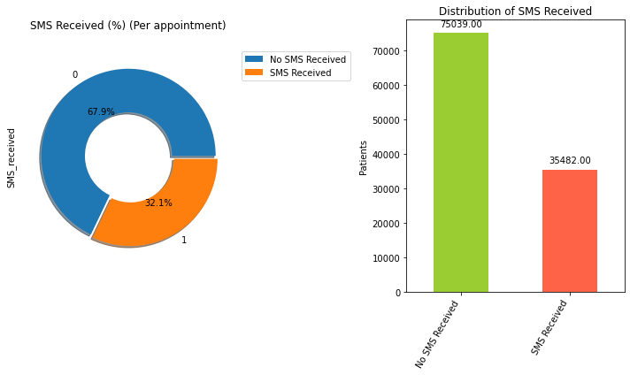

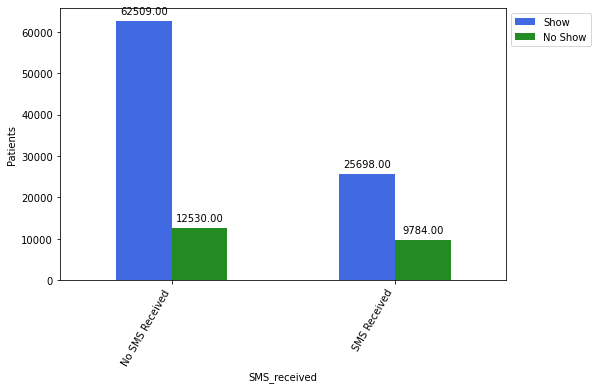

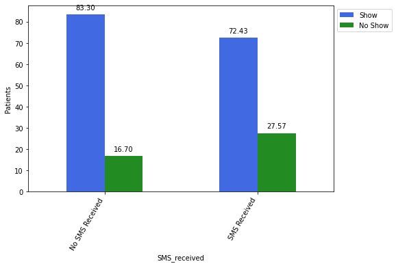

```python
### Plotting SMS_Received Distribution wrt Show vs No Show
fig = plt.subplots(figsize=(10,6))

plt.subplot(1,2,1)
df_pie = (df['SMS_received'].value_counts()/100)
ax1 = df_pie.plot.pie(shadow=True, explode=(0, 0.04), autopct='%1.1f%%',wedgeprops=dict(width=0.5))
ax1.set_title('SMS Received (%) (Per appointment)\n');
ax1.legend(labels=["No SMS Received", "SMS Received"],loc = 'upper left',bbox_to_anchor=(1.0,1.0))

plt.subplot(1,2,2)
df_bar = df['SMS_received'].value_counts()
ax2 = df_bar.plot.bar(color=['yellowgreen','tomato'])
ax2.set_xticklabels(["No SMS Received", "SMS Received"], rotation=60, ha="right")
ax2.set_ylabel("Patients")
ax2.set_title('Distribution of SMS Received')
autolabel(ax2)
plt.tight_layout()

df_count = pd.crosstab(df['SMS_received'], df['No_show'])
ax3 = df_count.plot.bar(figsize=(8,5), color=['royalblue','forestgreen'])
ax3.set_xticklabels(["No SMS Received", "SMS Received"], rotation=60, ha="right")
ax3.set_ylabel("Patients")
ax3.legend(labels=['Show', 'No Show'],loc = 'upper left',bbox_to_anchor=(1.0,1.0))
autolabel(ax3)

df_count = pd.crosstab(df['SMS_received'], df['No_show'], normalize = 'index')*100
ax4 = df_count.plot.bar(figsize=(8,5), color=['royalblue','forestgreen'])
ax4.set_xticklabels(["No SMS Received", "SMS Received"], rotation=60, ha="right")
ax4.set_ylabel("Patients")
ax4.legend(labels=['Show', 'No Show'],loc = 'upper left',bbox_to_anchor=(1.0,1.0))
autolabel(ax4)

plt.show()
```

- Patients didn't receive an SMS is 67.9%, where patients received an SMS is 32.1%.
- Show-up rate of patients who didn't receive an SMS reminder is the highest with 83.3%, where the show-up rate of patients who received an SMS reminder is 72.43%.

```python
neighborhood = df.Neighbourhood.unique()
neighborhood.sort()
```

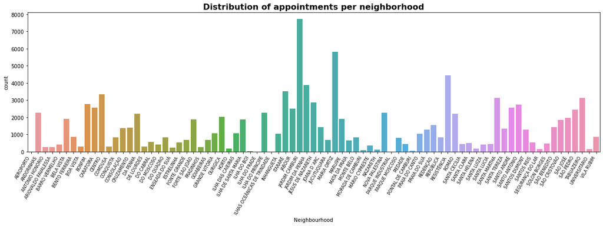

```python
## Plotting an histogram with the neighborhoods sorted alphabetically.
plt.figure(figsize=(20,5))
ax = sns.countplot(x='Neighbourhood', data=df, order=neighborhood)
ax.set_xticklabels(ax.get_xticklabels(), rotation=60, ha="right", fontsize=8)
plt.title('Distribution of appointments per neighborhood', fontsize=16, fontweight='semibold')
plt.show()
```

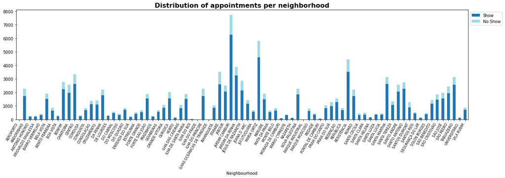

```python
df_count = pd.crosstab(df['Neighbourhood'], df['No_show'])
ax = df_count.plot.bar(stacked = True, figsize=(20,5), cmap = 'tab20');
ax.set_xticklabels(neighborhood, rotation=60, ha="right", fontsize=8)
ax.legend(labels=['Show', 'No Show'],loc = 'upper left',bbox_to_anchor=(1.0,1.0))
plt.title('Distribution of appointments per neighborhood', fontsize=16, fontweight='semibold')
plt.show()
```

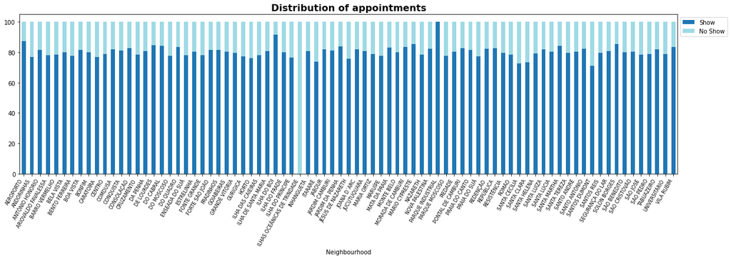

```python
df_count = pd.crosstab(df['Neighbourhood'], df['No_show'], normalize = 'index')*100
ax = df_count.plot.bar(stacked = True, figsize=(20,5), cmap = 'tab20');
ax.set_xticklabels(neighborhood, rotation=60, ha="right", fontsize=8)
ax.legend(labels=['Show', 'No Show'],loc = 'upper left',bbox_to_anchor=(1.0,1.0))
plt.title('Distribution of appointments', fontsize=16, fontweight='semibold')
plt.show()
```

- 80% of the appointments have attended.
- Neighborhood Parque Industrial had attended all its appointments but the same neighborhood carries the lowest number of appointments.

### Conclusion

Running statistical analyses on these areas would be a good next step to better understand which of these factors impact appointment show rates the most and hone in on what conditions yield better appointment show rates.

### Limitation

- One main limitation i faced was lack of enough data regarding the patient's home address. One question i had in mind was
- Is the clinic too far away from their house as a factor for people not showing up for their appointments?
- Since I would see the neighbourhood column and it is the hospital location but no patient home address or any distance value.

> Reference point: https://www.w3schools.com/python/matplotlib_pie_charts.asp